# Nigeria Crop Consumption

#### Wheat consumption

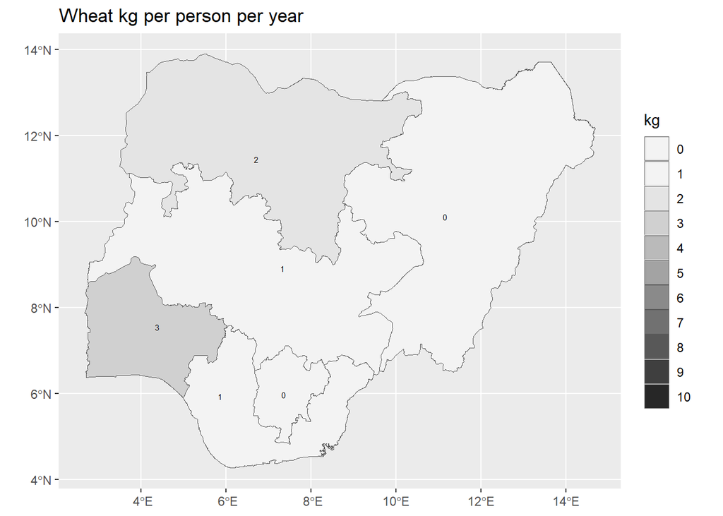

```r
ggplot(tidyterra::filter(vect_gpz_geo_GHS_crop, crop == "Wheat")) +
  geom_spatvector(aes(fill = crop_equivalent_kg_person_year)) +
  geom_spatvector_text(aes(label = round(crop_equivalent_kg_person_year)), size = 2) +
  scale_fill_stepsn(
    n.breaks = 10,
    limits = c(0, 10),
    colours = hcl.colors(palette = "Grays", 10, rev = T),
    guide = "legend",
    na.value = "pink",
    labels = scales::comma
  ) +
  labs(title = "Wheat kg per person per year", fill = "kg") +
  theme(
    plot.title = element_markdown(),
    legend.title = element_markdown(),
    axis.title = element_blank()
  )
```

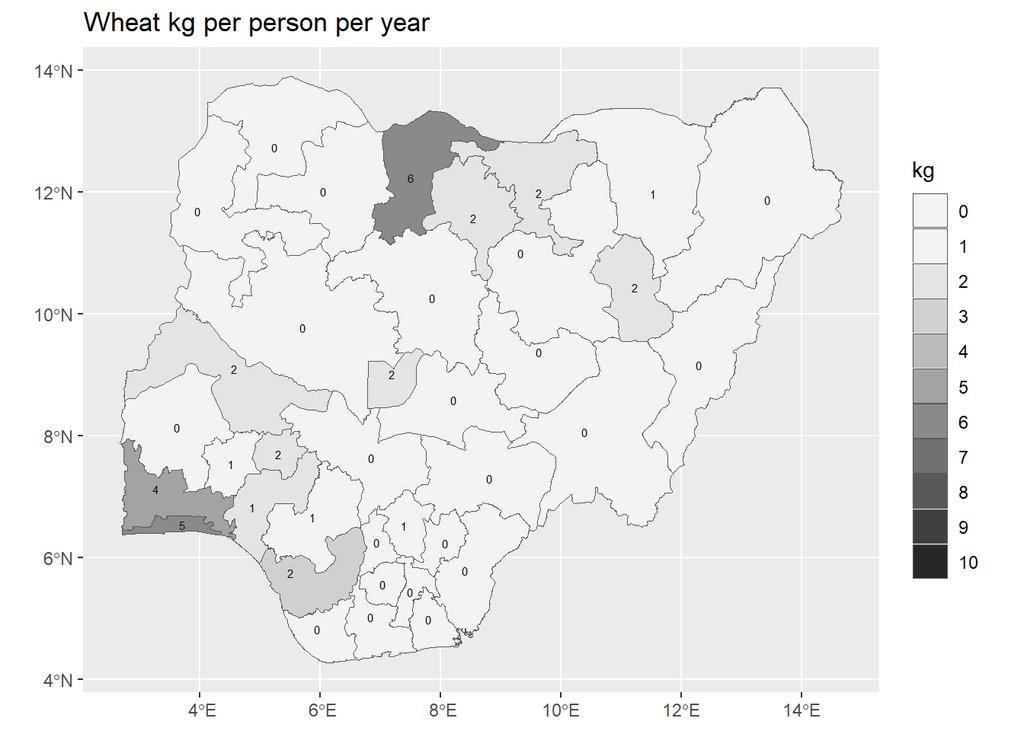

```r
ggplot(tidyterra::filter(vect_state_geo_GHS_crop, crop == "Wheat")) +
  geom_spatvector(aes(fill = crop_equivalent_kg_person_year)) +
  geom_spatvector_text(aes(label = round(crop_equivalent_kg_person_year)), size = 2) +
  scale_fill_stepsn(
    n.breaks = 10,
    limits = c(0, 10),
    colours = hcl.colors(palette = "Grays", 10, rev = T),
    guide = "legend",
    na.value = "pink",
    labels = scales::comma
  ) +
  labs(title = "Wheat kg per person per year", fill = "kg") +
  theme(
    plot.title = element_markdown(),
    legend.title = element_markdown(),
    axis.title = element_blank()
  )
```

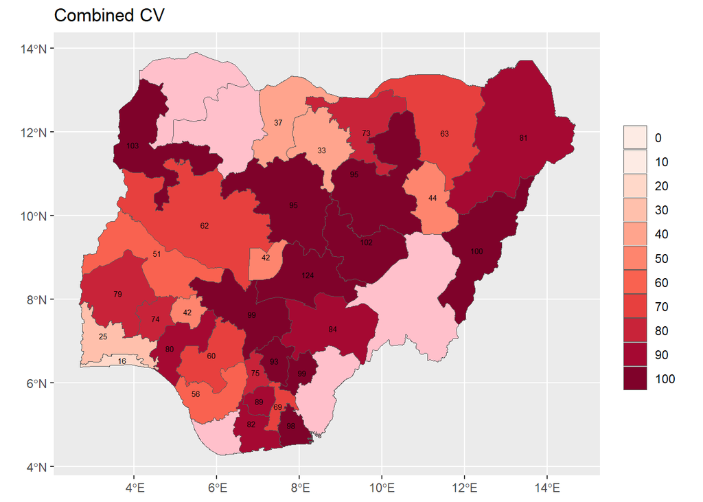

```r
ggplot(tidyterra::filter(vect_state_geo_GHS_crop, crop == "Wheat")) +
  geom_spatvector(aes(fill = crop_cv_combined)) +
  geom_spatvector_text(aes(label = round(crop_cv_combined)), size = 2) +
  scale_fill_stepsn(
    n.breaks = 10,
    limits = c(0, 100),
    colours = hcl.colors(palette = "Reds", 6, rev = T),
    guide = "legend",
    na.value = "pink",
    labels = scales::comma
  ) +
  labs(title = "Combined CV", fill = NA) +
  theme(
    plot.title = element_markdown(),
    legend.title = element_markdown(),
    axis.title = element_blank()
  )
```

#### Yam consumption

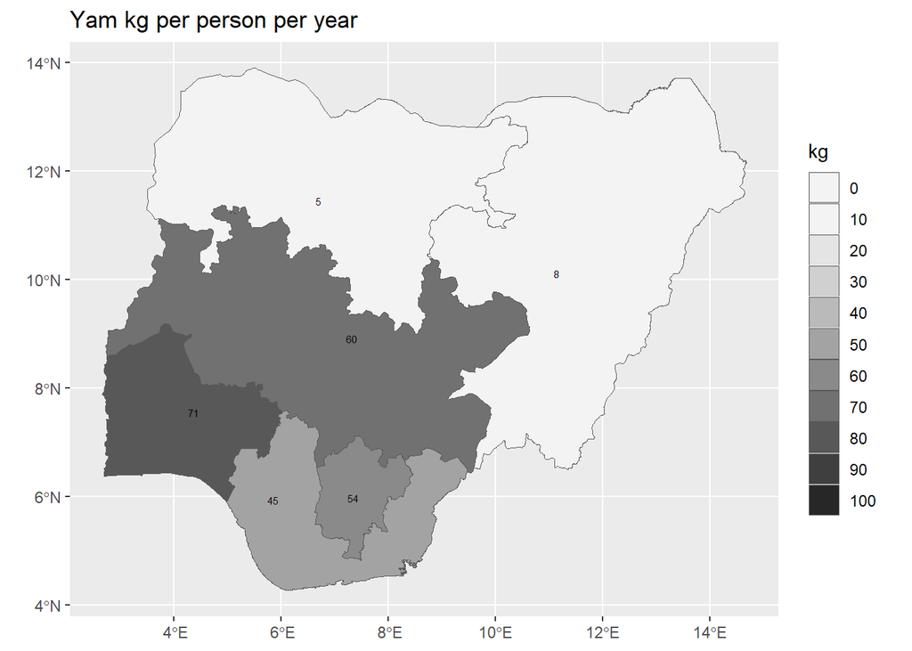

```r
ggplot(tidyterra::filter(vect_gpz_geo_GHS_crop, crop == "Yam")) +
  geom_spatvector(aes(fill = crop_equivalent_kg_person_year)) +
  geom_spatvector_text(aes(label = round(crop_equivalent_kg_person_year)), size = 2) +
  scale_fill_stepsn(
    n.breaks = 10,
    limits = c(0, 100),
    colours = hcl.colors(palette = "Grays", 10, rev = T),
    guide = "legend",
    na.value = "pink",
    labels = scales::comma
  ) +
  labs(title = "Yam kg per person per year", fill = "kg") +
  theme(
    plot.title = element_markdown(),
    legend.title = element_markdown(),
    axis.title = element_blank()
  )
```

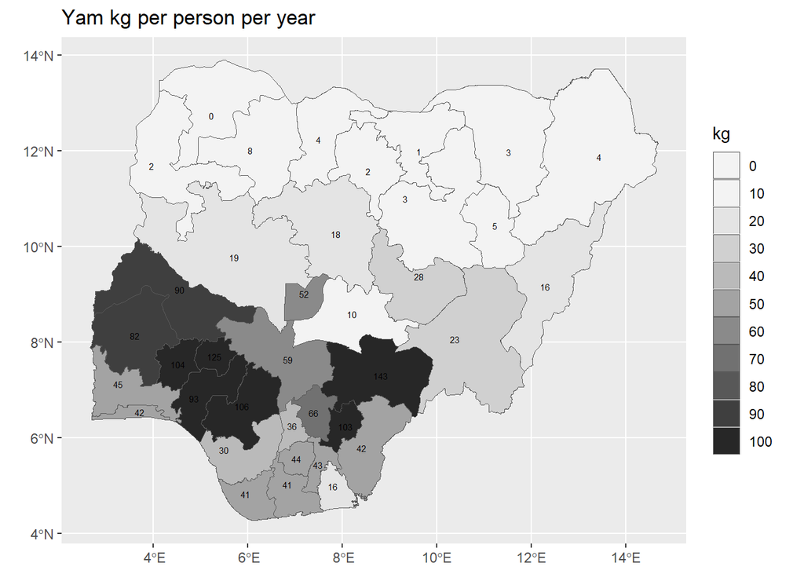

```r
ggplot(tidyterra::filter(vect_state_geo_GHS_crop, crop == "Yam")) +
  geom_spatvector(aes(fill = crop_equivalent_kg_person_year)) +
  geom_spatvector_text(aes(label = round(crop_equivalent_kg_person_year)), size = 2) +
  scale_fill_stepsn(
    n.breaks = 10,
    limits = c(0, 100),
    colours = hcl.colors(palette = "Grays", 10, rev = T),
    guide = "legend",
    na.value = "pink",
    labels = scales::comma
  ) +
  labs(title = "Yam kg per person per year", fill = "kg") +
  theme(
    plot.title = element_markdown(),
    legend.title = element_markdown(),
    axis.title = element_blank()
  )
```

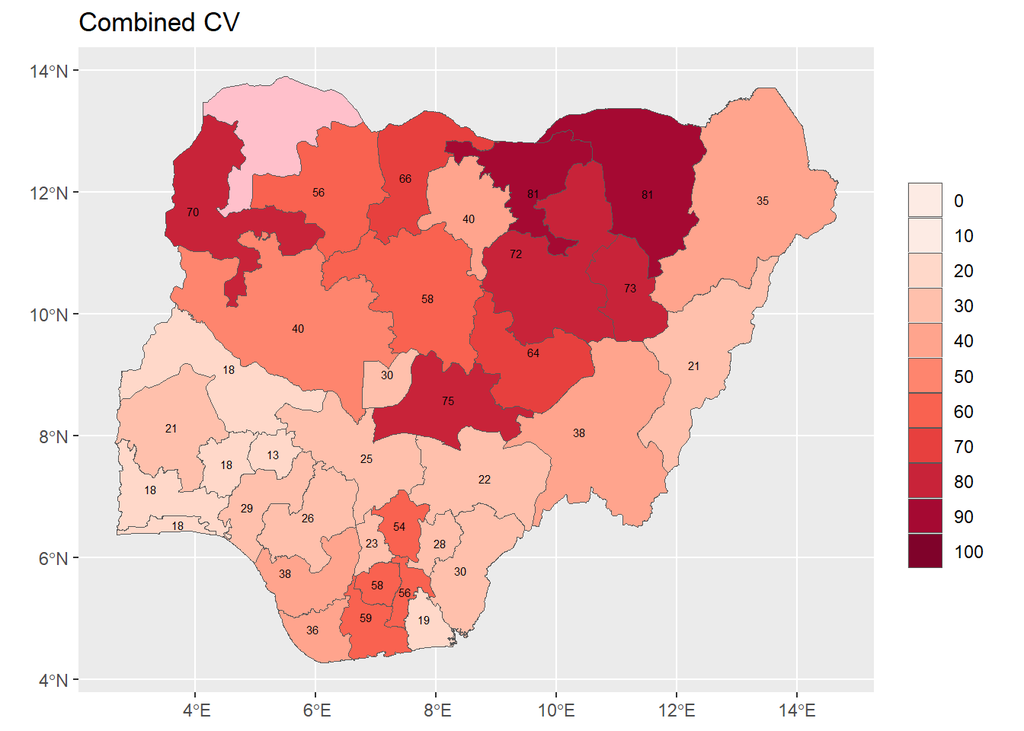

```r
ggplot(tidyterra::filter(vect_state_geo_GHS_crop, crop == "Yam")) +
  geom_spatvector(aes(fill = crop_cv_combined)) +
  geom_spatvector_text(aes(label = round(crop_cv_combined)), size = 2) +
  scale_fill_stepsn(
    n.breaks = 10,
    limits = c(0, 100),
    colours = hcl.colors(palette = "Reds", 6, rev = T),
    guide = "legend",
    na.value = "pink",
    labels = scales::comma
  ) +
  labs(title = "Combined CV", fill = NA) +
  theme(
    plot.title = element_markdown(),
    legend.title = element_markdown(),
    axis.title = element_blank()
  )
```

## Smoothed Crop Consumption

```r
# create queen neighbours
# Find Queen contiguity (default)
# queen_adj <- adjacent(vect_state_geo, type="queen", pairs=TRUE)

state_names <- vect_state_geo$adm1_ref_name
sf_polygons <- st_as_sf(vect_state_geo)|> st_make_valid()

# Build neighbour list (Queen contiguity)
nb_list <- poly2nb(sf_polygons, queen = TRUE)

#state_names

# Convert neighbour list to a spatial weights matrix
weights_list <- nb2listw(nb_list, style = "W",
  zero.policy = TRUE)

weights_matrix <- listw2mat(weights_list)

rownames(weights_matrix) <- state_names
colnames(weights_matrix) <- state_names
```

```r
df_GHS_pop_state_pp <- read.csv("tab_data/GHS food per capita outputs/GHS_wave5_food_consumption_state_planting.csv") |> select(state, zone, n_households,  n_psu, weighted_population, median_household_size, mean_household_size) |> distinct()

df_GHS_pop_state_pp <- df_GHS_pop_state_pp |>
  mutate(state = trimws(gsub("[^A-Za-z ]", "", state)))
df_GHS_pop_state_pp <- df_GHS_pop_state_pp |>
  mutate(zone = trimws(gsub("[^A-Za-z ]", "", zone)))

# change name to match states dataset
df_GHS_pop_state_pp['state'][df_GHS_pop_state_pp['state'] == "FCT"] <- "Federal Capital Territory"


df_GHS_pop_state_ph <- read.csv("tab_data/GHS food per capita outputs/GHS_wave5_food_consumption_state_harvest.csv") |> select(state, zone, n_households,   n_psu, weighted_population, median_household_size, mean_household_size) |> distinct()

df_GHS_pop_state_ph <- df_GHS_pop_state_ph |>
  mutate(state = trimws(gsub("[^A-Za-z ]", "", state)))
df_GHS_pop_state_ph <- df_GHS_pop_state_ph |>
  mutate(zone = trimws(gsub("[^A-Za-z ]", "", zone)))
df_GHS_pop_state_ph['state'][df_GHS_pop_state_ph['state'] == "FCT"] <- "Federal Capital Territory"

df_GHS_pop_state <- left_join(
  df_GHS_pop_state_pp,
  df_GHS_pop_state_ph,
  by = "state"
) |>
  rowwise() |>
  mutate(
    zone = zone.x,
    n_households = mean(c(n_households.x, n_households.y), na.rm = T),
    n_psu = mean(c(n_psu.x, n_psu.y), na.rm = T),
    weighted_population = mean(
      c(weighted_population.x, weighted_population.y),
      na.rm = T
    ),
    median_household_size = mean(
      c(median_household_size.x, median_household_size.y),
      na.rm = T
    ),
    mean_household_size = mean(
      c(mean_household_size.x, mean_household_size.y),
      na.rm = T
    )
  ) |>
  rename(
    n_households_pp = n_households.x,
    n_households_ph = n_households.y,
    n_psu_pp = n_psu.x,
    n_psu_ph = n_psu.y,
    mean_household_size_pp = mean_household_size.x,
    mean_household_size_ph = mean_household_size.y,
    median_household_size_pp = median_household_size.x,
    median_household_size_ph = median_household_size.y,
    weighted_population_pp = weighted_population.x,
    weighted_population_ph = weighted_population.y
  ) |>
  select(
    state,
    zone,
    weighted_population_pp,
    weighted_population_ph,
    weighted_population,
    n_households_pp,
    n_households_ph,
    n_households,
    n_psu_pp,
    n_psu_ph,
    n_psu,
    mean_household_size_pp,
    mean_household_size_ph,
    mean_household_size,
    median_household_size_pp,
    median_household_size_ph,
    median_household_size
  )


# get the zonal population

df_GHS_pop_zone <- df_GHS_pop_state |>
  group_by(
    zone
  ) |>
  summarise(
    weighted_population_zone = sum(weighted_population, na.rm = TRUE),
    .groups = "drop"
  )

# add zonal population to the state

df_GHS_pop_state <- df_GHS_pop_state |>
  left_join(df_GHS_pop_zone, by = "zone")
```

```r
df_GHS_pop_crop_state <- df_GHS_crop_state |>
  left_join(df_GHS_pop_state, by = c("state")) |>
    left_join(df_GHS_crop_zone, by = c("zone", "crop")) |>
rename(
    crop_equivalent_low_state = crop_equivalent_low.x,
    crop_equivalent_low_zone = crop_equivalent_low.y,
    crop_equivalent_kg_person_year_state = crop_equivalent_kg_person_year.x,
    crop_equivalent_kg_person_year_zone = crop_equivalent_kg_person_year.y,
    crop_equivalent_high_state = crop_equivalent_high.x,
    crop_equivalent_high_zone = crop_equivalent_high.y)
```

### Spatial lag to smooth state estimates

```r
# ============================================================
# 1. INPUTS
# ============================================================

# Expected columns in df_GHS_pop_crop_state  :
#
# crop
# state
# zone
# crop_equivalent_kg_person_year_state       = direct state kg/person/year
# crop_equivalent_kg_person_year_zone        = survey-supported zone kg/person/year
# weighted_population     = weighted population of state
# weighted_population_zone      = weighted population of zone
#
# weights_matrix = row-standardised queen spatial weights matrix
#
# IMPORTANT:
# The rows/columns of weights_matrix must correspond to the STATE names
# used in df_GHS_pop_crop_state.
# ============================================================
```

```r
# ============================================================
# 2. CHECK THE POPULATION / ZONE INFORMATION
# ============================================================

zone_check <- df_GHS_pop_crop_state |>
  group_by(crop, zone) |>
  summarise(
    crop_equivalent_kg_person_year_zone = first(crop_equivalent_kg_person_year_zone),
    weighted_population_zone = first(weighted_population_zone),

    sum_weighted_population =
      sum(weighted_population, na.rm = TRUE),

    n_states = n(),

    .groups = "drop"
  ) |>
  mutate(
    population_difference =
      sum_weighted_population - weighted_population_zone
  )

zone_check |>
  DT::datatable(
    rownames = F,
    colnames=c("Crop", "Zone", "Zone crop consumption estimate" ,"weighted population per zone", "sum_weighted_population ", "# States ", "Population Difference "),
    caption = "Check the Population per zone",
    selection = list(mode = "none"),
    editable = FALSE,
    options = list(
      digits = 0,
      scrollX = TRUE,
      scrollCollapse = TRUE,
      # autoWidth = TRUE,
      fixedColumns = list(leftColumns = 2),
      lengthMenu = c(15, 40),
      pageLength = 15
    ))
```

Table 19: Zone check

| Crop | Zone | Zone crop consumption estimate | weighted population per zone | sum_weighted_population | # States | Population Difference |
| --- | --- | --- | --- | --- | --- | --- |
| Cassava | North Central | 89.23083919541823 | 33271143.54525127 | 33271143.54525127 | 7 | 0 |
| Cassava | North East | 65.54746658433292 | 32648367.78098391 | 32648367.78098391 | 6 | 0 |
| Cassava | North West | 60.25888427734957 | 63064815.14721394 | 63064815.14721394 | 7 | 0 |
| Cassava | South East | 154.7493714964525 | 24469631.60948114 | 24469631.60948114 | 5 | 0 |
| Cassava | South South | 233.8460665047694 | 31222076.03572947 | 31222076.03572947 | 6 | 0 |
| Cassava | South West | 106.1408605129903 | 42686077.57844689 | 42686077.57844689 | 6 | 0 |
| Cocoyam | North Central | 0.4077475554690789 | 33271143.54525127 | 33271143.54525127 | 7 | 0 |
| Cocoyam | North East | 0.1042285673410652 | 32648367.78098391 | 32648367.78098391 | 6 | 0 |
| Cocoyam | North West | 0.2476040690610698 | 63064815.14721394 | 63064815.14721394 | 7 | 0 |
| Cocoyam | South East | 5.546484673351984 | 24469631.60948114 | 24469631.60948114 | 5 | 0 |

[output cut: 74 more lines]

```r
# ============================================================
# 3. CALCULATE THE DIRECT STATE / ZONE RATIO
# ============================================================

df_GHS_pop_crop_state <- df_GHS_pop_crop_state |>
  mutate(
    state_zone_ratio =
      crop_equivalent_kg_person_year_state / crop_equivalent_kg_person_year_zone
  )
```

```r
# ============================================================
# 4. SPATIAL LAG OF THE STATE / ZONE RATIO
# ============================================================

# Convert weights_matrix to a matrix if necessary.
#
# If weights_matrix is already a matrix:
weights_matrix_mat <- as.matrix(weights_matrix)

# Check dimensions
stopifnot(
  nrow(weights_matrix_mat) == ncol(weights_matrix_mat)
)

# ------------------------------------------------------------
# IMPORTANT:
# We need the states in df_GHS_pop_crop_state to be in exactly the same order
# as the rows/columns of weights_matrix.
# ------------------------------------------------------------

state_order <- rownames(weights_matrix_mat)

if (is.null(state_order)) {
  stop(
    "weights_matrix must have state names as row names."
  )
}


# Check that every state in df_GHS_pop_crop_state occurs in weights_matrix
missing_states <- setdiff(
  unique(df_GHS_pop_crop_state$state),
  state_order
)

if (length(missing_states) > 0) {

  stop(
    "These states are missing from weights_matrix: ",
    paste(missing_states, collapse = ", ")
  )
}


# ------------------------------------------------------------
# Function to calculate spatially lagged ratios
# ------------------------------------------------------------

spatial_lag_ratio <- function(
    state_names,
    values,
    weights_matrix_mat
) {

  # Put values into the same order as weights_matrix
  x <- setNames(
    values,
    state_names
  )

  x_ordered <- x[
    rownames(weights_matrix_mat)
  ]

  # Spatial lag
  lagged <- as.numeric(
    weights_matrix_mat %*% x_ordered
  )

  names(lagged) <-
    rownames(weights_matrix_mat)

  # Return in original state order
  lagged[state_names]
}


# ------------------------------------------------------------
# Apply to each crop
#
# We calculate the spatial lag separately for each crop.
# ------------------------------------------------------------

df_GHS_pop_crop_state <- df_GHS_pop_crop_state |>
  group_by(crop) |>
  mutate(
    spatial_lag_ratio =
      spatial_lag_ratio(
        state,
        state_zone_ratio,
        weights_matrix_mat
      )
  ) |>
  ungroup()
```

```r
# ============================================================
# 5. CREATE THE UNBENCHMARKED SPATIAL ESTIMATE
# ============================================================

df_GHS_pop_crop_state <- df_GHS_pop_crop_state |>
  mutate(
    smoothed_ratio =
      spatial_lag_ratio,

    smoothed_crop_equivalent_kg_person_year_state =
      #smoothed_ratio * crop_equivalent_kg_person_year_zone
      smoothed_ratio * crop_equivalent_kg_person_year_state
  )
```

```r
# ============================================================
# 6. CALCULATE THE UNBENCHMARKED STATE TOTAL
# ============================================================

df_GHS_pop_crop_state <- df_GHS_pop_crop_state |>
  mutate(
    smoothed_state_total =
      smoothed_crop_equivalent_kg_person_year_state *
      weighted_population
  )
```

```r
# ============================================================
# 7. CALCULATE THE ZONAL BENCHMARK
# ============================================================

# The benchmark is:
#
# zone consumption =
# zone per-capita consumption × zone population
#
# We compare this with the population-weighted total of
# the spatially smoothed state estimates.

benchmark <- df_GHS_pop_crop_state |>
  group_by(crop, zone) |>
  summarise(

    crop_equivalent_kg_person_year_zone =
      first(crop_equivalent_kg_person_year_zone),

    weighted_population_zone =
      first(weighted_population_zone),

    zone_total =
      crop_equivalent_kg_person_year_zone *
      weighted_population_zone,

    smoothed_state_total =
      sum(
        smoothed_state_total,
        na.rm = TRUE
      ),

    .groups = "drop"
  ) |>
  mutate(

    benchmark_factor =
      zone_total /
      smoothed_state_total

  )
```

```r
# ============================================================
# 8. APPLY THE BENCHMARK
# ============================================================

df_GHS_pop_crop_state <- df_GHS_pop_crop_state |>

  left_join(
    benchmark |>
      select(
        crop,
        zone,
        benchmark_factor
      ),
    by = c(
      "crop",
      "zone"
    )
  ) |>

  mutate(

    benchmarked_crop_equivalent_kg_person_year_state =
      smoothed_crop_equivalent_kg_person_year_state *
      benchmark_factor,

    benchmarked_state_total =
      benchmarked_crop_equivalent_kg_person_year_state *
      weighted_population

  )
```

```r
# ============================================================
# 9. FINAL CHECK
# ============================================================

benchmark_check <- df_GHS_pop_crop_state |>

  group_by(
    crop,
    zone
  ) |>

  summarise(

    crop_equivalent_kg_person_year_zone =
      first(crop_equivalent_kg_person_year_zone),

    weighted_population_zone =
      first(weighted_population_zone),

    zone_total =
      crop_equivalent_kg_person_year_zone *
      weighted_population_zone,

    benchmarked_state_total =
      sum(
        benchmarked_state_total,
        na.rm = TRUE
      ),

    difference =
      benchmarked_state_total -
      zone_total,

    percentage_difference =
      100 *
      difference /
      zone_total,

    .groups = "drop"

  )

benchmark_check |>
  DT::datatable(
    rownames = F,
    colnames=c("Crop", "Zone", "Zone crop consumption estimate" ,"weighted population per zone", "Total consumption per zone", "benchmarked_state_total  ", "Consumption Difference ", "% Difference "),
    caption = "Check the Benchmark",
    selection = list(mode = "none"),
    editable = FALSE,
    options = list(
      digits = 0,
      scrollX = TRUE,
      scrollCollapse = TRUE,
      # autoWidth = TRUE,
      fixedColumns = list(leftColumns = 2),
      lengthMenu = c(15, 40),
      pageLength = 15
    ))
```

Table 20: Benchmark check

| Crop | Zone | Zone crop consumption estimate | weighted population per zone | Total consumption per zone | benchmarked_state_total | Consumption Difference | % Difference |
| --- | --- | --- | --- | --- | --- | --- | --- |
| Cassava | North Central | 89.23083919541823 | 33271143.54525127 | 2968812059.533993 | 2968812059.533992 | -4.76837158203125e-07 | -1.606154746885436e-14 |
| Cassava | North East | 65.54746658433292 | 32648367.78098391 | 2140017796.157055 | 2140017796.157055 | 0 | 0 |
| Cassava | North West | 60.25888427734957 | 63064815.14721394 | 3800215397.928407 | 3800215397.928407 | 0 | 0 |
| Cassava | South East | 154.7493714964525 | 24469631.60948114 | 3786660112.316934 | 3786660112.316934 | 0 | 0 |
| Cassava | South South | 233.8460665047694 | 31222076.03572947 | 7301159669.068161 | 7301159669.068161 | 0 | 0 |
| Cassava | South West | 106.1408605129903 | 42686077.57844689 | 4530737006.100613 | 4530737006.100613 | 0 | 0 |
| Cocoyam | North Central | 0.4077475554690789 | 33271143.54525127 | 13566227.44823703 | 13566227.44823703 | 0 | 0 |
| Cocoyam | North East | 0.1042285673410652 | 32648367.78098391 | 3402892.599836144 | 3402892.599836144 | 4.656612873077393e-10 | 1.368427811474749e-14 |
| Cocoyam | North West | 0.2476040690610698 | 63064815.14721394 | 15615104.84503436 | 15615104.84503436 | 0 | 0 |
| Cocoyam | South East | 5.546484673351984 | 24469631.60948114 | 135720436.6845564 | 135720436.6845564 | 0 | 0 |

[output cut: 74 more lines]

```r
# ============================================================
# 10. SAVE OUTPUTS
# ============================================================


write_csv(
  df_GHS_pop_crop_state,
  "tab_data/GHS food per capita outputs/crop_state_results_benchmarked_smoothed.csv"
)
```

### Join back to States dataset

```r
vect_state_geo_GHS_crop <- dplyr::left_join(vect_state_geo, df_GHS_pop_crop_state, by = c("adm1_ref_name" = "state"))
vect_state_geo_GHS_crop |>
  as.data.frame() |>
  select(
    zone,
    adm1_ref_name,
    crop,
    crop_equivalent_kg_person_year_state,
    crop_equivalent_kg_person_year_zone,
    benchmarked_crop_equivalent_kg_person_year_state
  ) |>
  mutate(
    crop_equivalent_kg_person_year_state = prettyunits::pretty_round(
      crop_equivalent_kg_person_year_state,
      digits = 0
    ),
    crop_equivalent_kg_person_year_zone = prettyunits::pretty_round(crop_equivalent_kg_person_year_zone, digits = 0),
    benchmarked_crop_equivalent_kg_person_year_state = prettyunits::pretty_round(
      benchmarked_crop_equivalent_kg_person_year_state,
      digits = 0
    )
  ) |>
  DT::datatable(
    rownames = F,
    colnames = c(
      "Zone",
      "State",
      "Crop",
      "State - Annual Per Capita consumption (kg)",
      "Zone - Annual Per Capita consumption (kg)",
      "State Smoothed Benchmarked - Annual Per Capita consumption (kg)"
    ),
    caption = "GHS crop consumption zone summary",
    filter = "bottom",
    selection = list(mode = "none"),
    editable = FALSE,
    options = list(
      digits = 0,
      scrollX = TRUE,
      scrollCollapse = TRUE,
      autoWidth = TRUE,
      fixedColumns = list(leftColumns = 2),
      lengthMenu = c(15, 40),
      pageLength = 15
    )
  )
```

| Zone | State | Crop | State - Annual Per Capita consumption (kg) | Zone - Annual Per Capita consumption (kg) | State Smoothed Benchmarked - Annual Per Capita consumption (kg) |
| --- | --- | --- | --- | --- | --- |
| South East | Abia | Cassava | 129 | 155 | 135 |
| South East | Abia | Cocoyam | 0 | 6 | 1 |
| South East | Abia | Cowpea | 13 | 11 | 12 |
| South East | Abia | Groundnut | 2 | 2 | 2 |
| South East | Abia | Maize | 10 | 11 | 10 |
| South East | Abia | Millet | 0 | 0 | 0 |
| South East | Abia | Plantain | 9 | 8 | 10 |
| South East | Abia | Potato | 1 | 0 | 1 |
| South East | Abia | Rice | 26 | 27 | 26 |
| South East | Abia | Sorghum | 0 | 0 | 0 |

[output cut: 508 more lines]

### Plot the benchmarked and smoothed consumption results

#### Cassava consumption

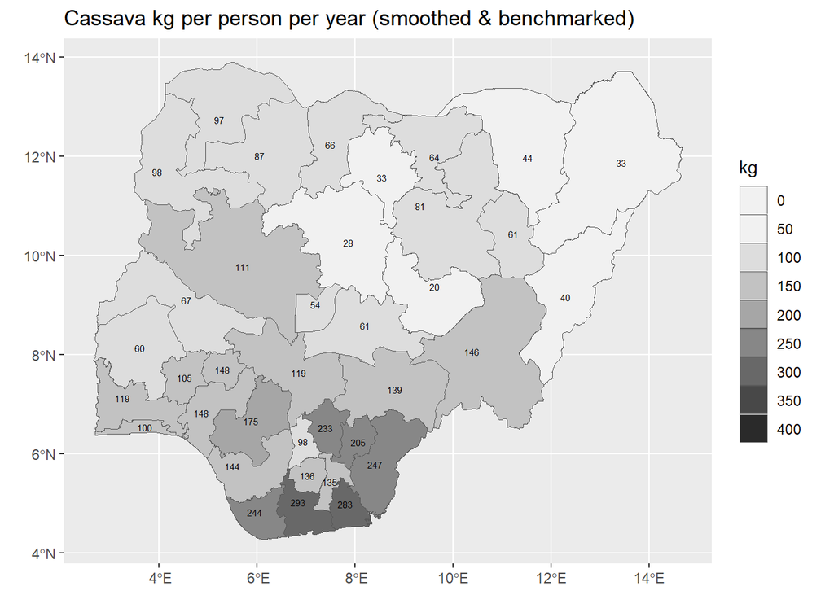

```r
ggplot(tidyterra::filter(vect_state_geo_GHS_crop, crop == "Cassava")) +
  geom_spatvector(aes(fill = benchmarked_crop_equivalent_kg_person_year_state)) +
  geom_spatvector_text(aes(label = round(benchmarked_crop_equivalent_kg_person_year_state)), size = 2) +
  scale_fill_stepsn(
    n.breaks = 10,
    limits = c(0, 400),
    colours = hcl.colors(palette = "Grays", 10, rev = T),
    guide = "legend",
    na.value = "pink",
    labels = scales::comma
  ) +
  labs(title = "Cassava kg per person per year (smoothed & benchmarked)", fill = "kg") +
  theme(
    plot.title = element_markdown(),
    legend.title = element_markdown(),
    axis.title = element_blank()
  )
```

#### Cocoyam consumption

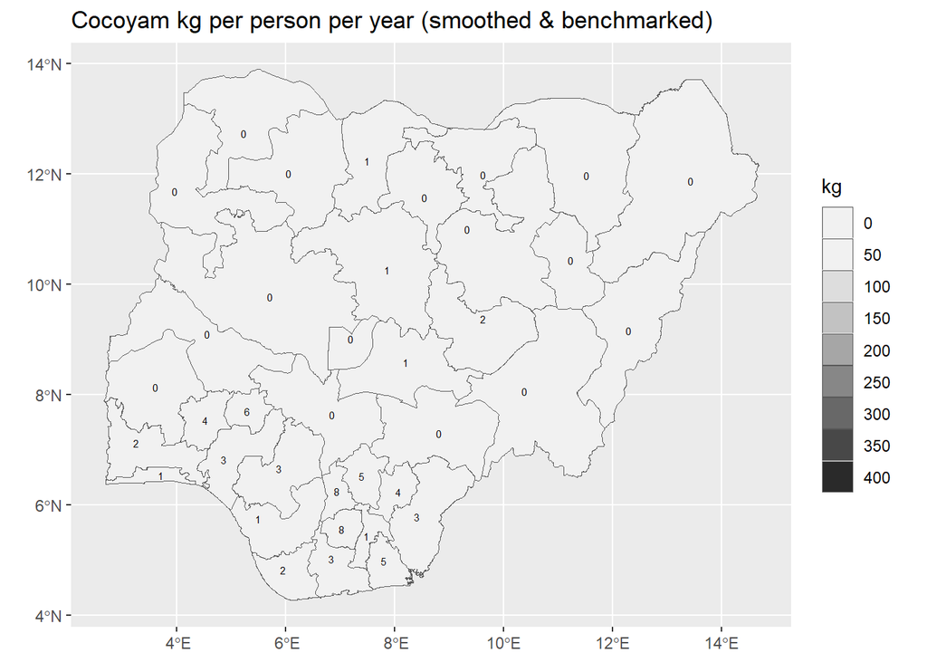

```r
ggplot(tidyterra::filter(vect_state_geo_GHS_crop, crop == "Cocoyam")) +
  geom_spatvector(aes(fill = benchmarked_crop_equivalent_kg_person_year_state)) +
  geom_spatvector_text(aes(label = round(benchmarked_crop_equivalent_kg_person_year_state)), size = 2) +
  scale_fill_stepsn(
    n.breaks = 10,
    limits = c(0, 400),
    colours = hcl.colors(palette = "Grays", 10, rev = T),
    guide = "legend",
    na.value = "pink",
    labels = scales::comma
  ) +
  labs(title = "Cocoyam kg per person per year (smoothed & benchmarked)", fill = "kg") +
  theme(
    plot.title = element_markdown(),
    legend.title = element_markdown(),
    axis.title = element_blank()
  )
```

#### Cowpea consumption

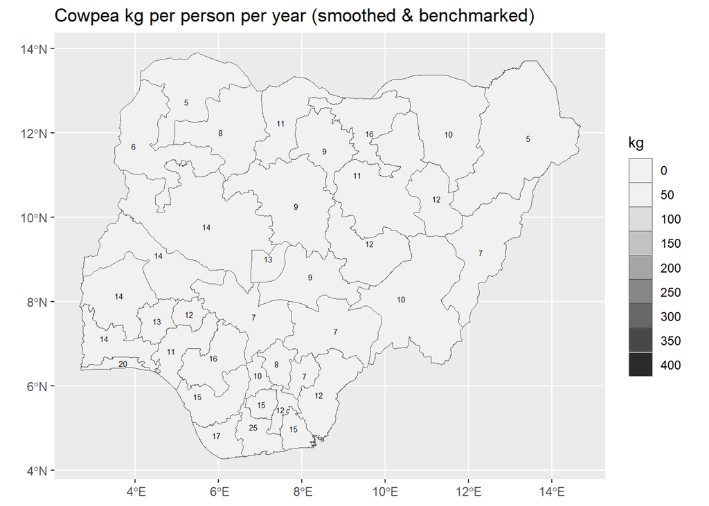

```r
ggplot(tidyterra::filter(vect_state_geo_GHS_crop, crop == "Cowpea")) +
  geom_spatvector(aes(fill = benchmarked_crop_equivalent_kg_person_year_state)) +
  geom_spatvector_text(aes(label = round(benchmarked_crop_equivalent_kg_person_year_state)), size = 2) +
  scale_fill_stepsn(
    n.breaks = 10,
    limits = c(0, 400),
    colours = hcl.colors(palette = "Grays", 10, rev = T),
    guide = "legend",
    na.value = "pink",
    labels = scales::comma
  ) +
  labs(title = "Cowpea kg per person per year (smoothed & benchmarked)", fill = "kg") +
  theme(
    plot.title = element_markdown(),
    legend.title = element_markdown(),
    axis.title = element_blank()
  )
```

#### Maize consumption

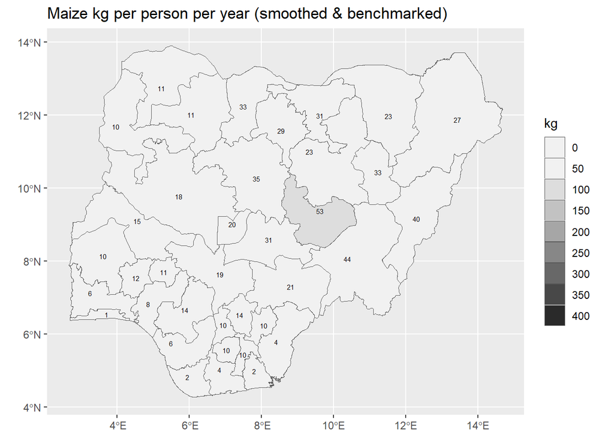

```r
ggplot(tidyterra::filter(vect_state_geo_GHS_crop, crop == "Maize")) +
  geom_spatvector(aes(fill = benchmarked_crop_equivalent_kg_person_year_state)) +
  geom_spatvector_text(aes(label = round(benchmarked_crop_equivalent_kg_person_year_state)), size = 2) +
  scale_fill_stepsn(
    n.breaks = 10,
    limits = c(0, 400),
    colours = hcl.colors(palette = "Grays", 10, rev = T),
    guide = "legend",
    na.value = "pink",
    labels = scales::comma
  ) +
  labs(title = "Maize kg per person per year (smoothed & benchmarked)", fill = "kg") +
  theme(
    plot.title = element_markdown(),
    legend.title = element_markdown(),
    axis.title = element_blank()
  )
```

#### Millet consumption

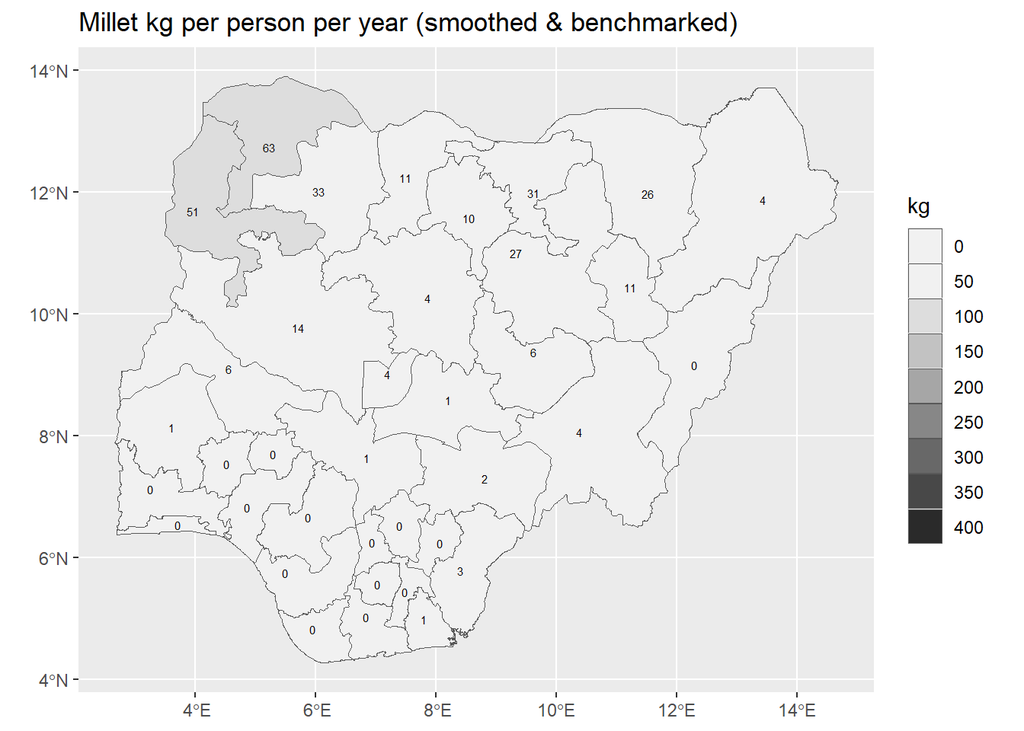

```r
ggplot(tidyterra::filter(vect_state_geo_GHS_crop, crop == "Millet")) +
  geom_spatvector(aes(fill = benchmarked_crop_equivalent_kg_person_year_state)) +
  geom_spatvector_text(aes(label = round(benchmarked_crop_equivalent_kg_person_year_state)), size = 2) +
  scale_fill_stepsn(
    n.breaks = 10,
    limits = c(0, 400),
    colours = hcl.colors(palette = "Grays", 10, rev = T),
    guide = "legend",
    na.value = "pink",
    labels = scales::comma
  ) +
  labs(title = "Millet kg per person per year (smoothed & benchmarked)", fill = "kg") +
  theme(
    plot.title = element_markdown(),
    legend.title = element_markdown(),
    axis.title = element_blank()
  )
```

#### Potato consumption

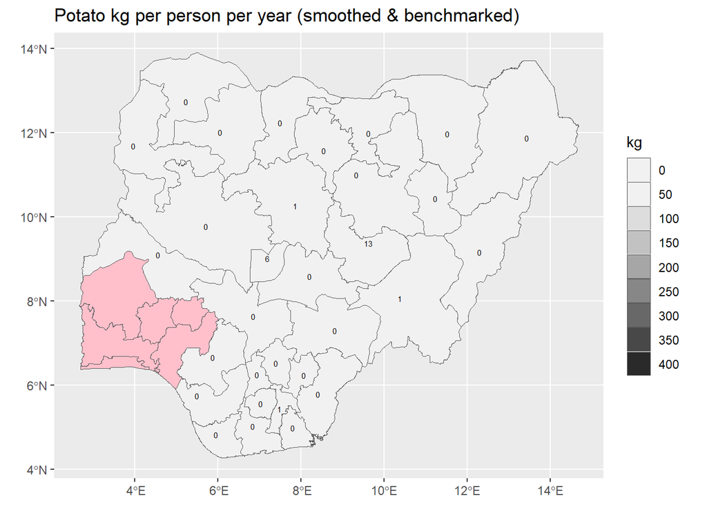

```r
ggplot(tidyterra::filter(vect_state_geo_GHS_crop, crop == "Potato")) +
  geom_spatvector(aes(fill = benchmarked_crop_equivalent_kg_person_year_state)) +
  geom_spatvector_text(aes(label = round(benchmarked_crop_equivalent_kg_person_year_state)), size = 2) +
  scale_fill_stepsn(
    n.breaks = 10,
    limits = c(0, 400),
    colours = hcl.colors(palette = "Grays", 10, rev = T),
    guide = "legend",
    na.value = "pink",
    labels = scales::comma
  ) +
  labs(title = "Potato kg per person per year (smoothed & benchmarked)", fill = "kg") +
  theme(
    plot.title = element_markdown(),
    legend.title = element_markdown(),
    axis.title = element_blank()
  )
```

#### Plantain consumption

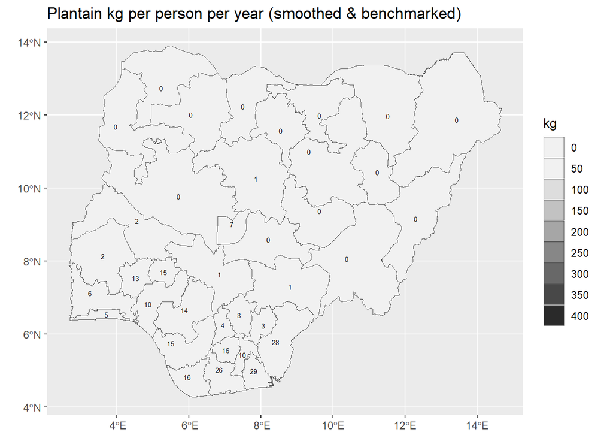

```r
ggplot(tidyterra::filter(vect_state_geo_GHS_crop, crop == "Plantain")) +
  geom_spatvector(aes(fill = benchmarked_crop_equivalent_kg_person_year_state)) +
  geom_spatvector_text(aes(label = round(benchmarked_crop_equivalent_kg_person_year_state)), size = 2) +
  scale_fill_stepsn(
    n.breaks = 10,
    limits = c(0, 400),
    colours = hcl.colors(palette = "Grays", 10, rev = T),
    guide = "legend",
    na.value = "pink",
    labels = scales::comma
  ) +
  labs(title = "Plantain kg per person per year (smoothed & benchmarked)", fill = "kg") +
  theme(
    plot.title = element_markdown(),
    legend.title = element_markdown(),
    axis.title = element_blank()
  )
```

#### Rice consumption

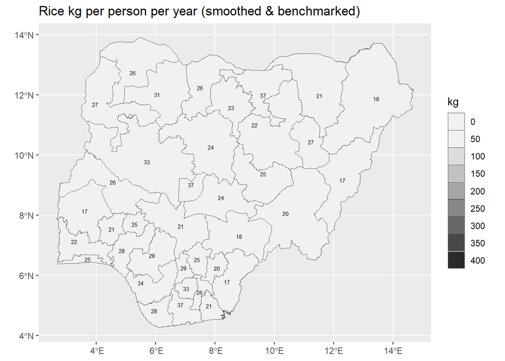

```r
ggplot(tidyterra::filter(vect_state_geo_GHS_crop, crop == "Rice")) +
  geom_spatvector(aes(fill = benchmarked_crop_equivalent_kg_person_year_state)) +
  geom_spatvector_text(aes(label = round(benchmarked_crop_equivalent_kg_person_year_state)), size = 2) +
  scale_fill_stepsn(
    n.breaks = 10,
    limits = c(0, 400),
    colours = hcl.colors(palette = "Grays", 10, rev = T),
    guide = "legend",
    na.value = "pink",
    labels = scales::comma
  ) +
  labs(title = "Rice kg per person per year (smoothed & benchmarked)", fill = "kg") +
  theme(
    plot.title = element_markdown(),
    legend.title = element_markdown(),
    axis.title = element_blank()
  )
```

#### Sorghum consumption

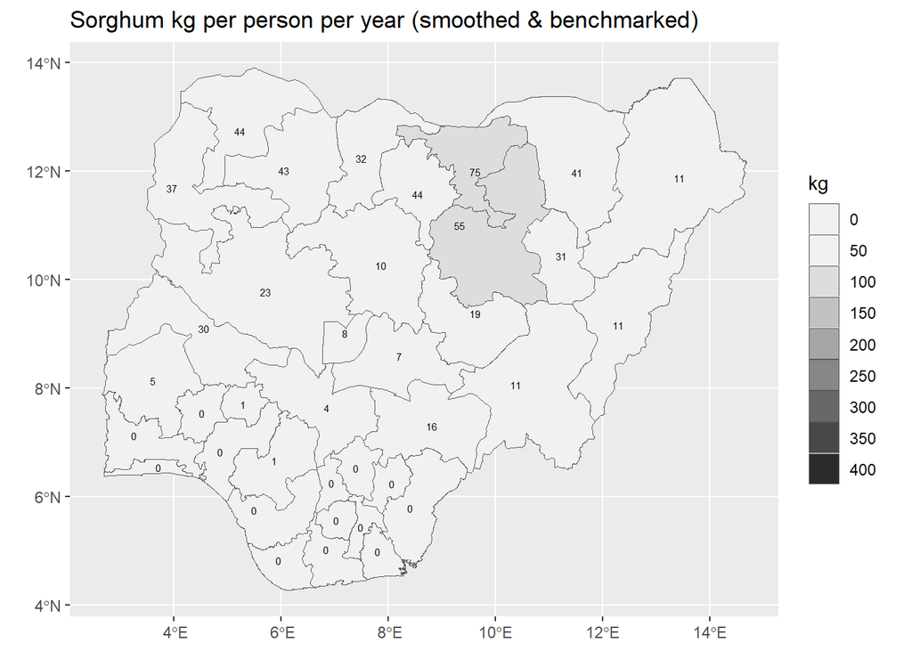

```r
ggplot(tidyterra::filter(vect_state_geo_GHS_crop, crop == "Sorghum")) +
  geom_spatvector(aes(fill = benchmarked_crop_equivalent_kg_person_year_state)) +
  geom_spatvector_text(aes(label = round(benchmarked_crop_equivalent_kg_person_year_state)), size = 2) +
  scale_fill_stepsn(
    n.breaks = 10,
    limits = c(0, 400),
    colours = hcl.colors(palette = "Grays", 10, rev = T),
    guide = "legend",
    na.value = "pink",
    labels = scales::comma
  ) +
  labs(title = "Sorghum kg per person per year (smoothed & benchmarked)", fill = "kg") +
  theme(
    plot.title = element_markdown(),
    legend.title = element_markdown(),
    axis.title = element_blank()
  )
```

#### Sweet Potato consumption

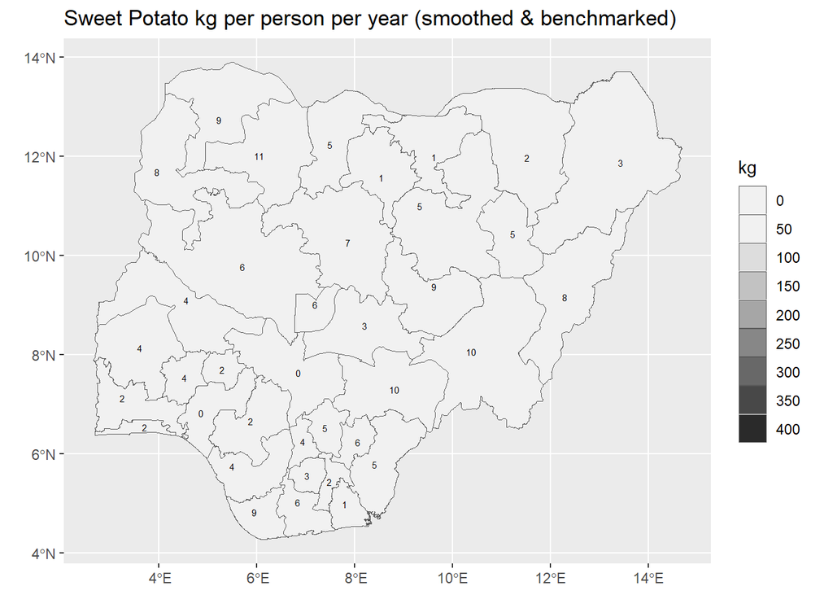

```r
ggplot(tidyterra::filter(vect_state_geo_GHS_crop, crop == "Sweet potato")) +
  geom_spatvector(aes(fill = benchmarked_crop_equivalent_kg_person_year_state)) +
  geom_spatvector_text(aes(label = round(benchmarked_crop_equivalent_kg_person_year_state)), size = 2) +
  scale_fill_stepsn(
    n.breaks = 10,
    limits = c(0, 400),
    colours = hcl.colors(palette = "Grays", 10, rev = T),
    guide = "legend",
    na.value = "pink",
    labels = scales::comma
  ) +
  labs(title = "Sweet Potato kg per person per year (smoothed & benchmarked)", fill = "kg") +
  theme(
    plot.title = element_markdown(),
    legend.title = element_markdown(),
    axis.title = element_blank()
  )
```

#### Wheat consumption

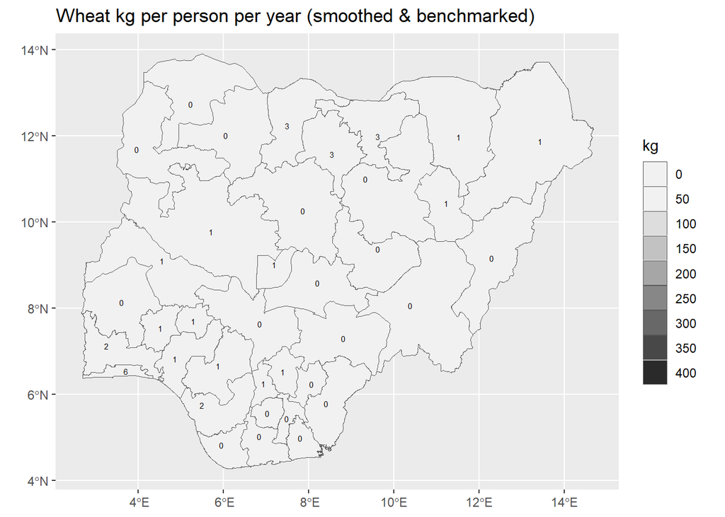

```r
ggplot(tidyterra::filter(vect_state_geo_GHS_crop, crop == "Wheat")) +
  geom_spatvector(aes(fill = benchmarked_crop_equivalent_kg_person_year_state)) +
  geom_spatvector_text(aes(label = round(benchmarked_crop_equivalent_kg_person_year_state)), size = 2) +
  scale_fill_stepsn(
    n.breaks = 10,
    limits = c(0, 400),
    colours = hcl.colors(palette = "Grays", 10, rev = T),
    guide = "legend",
    na.value = "pink",
    labels = scales::comma
  ) +
  labs(title = "Wheat kg per person per year (smoothed & benchmarked)", fill = "kg") +
  theme(
    plot.title = element_markdown(),
    legend.title = element_markdown(),
    axis.title = element_blank()
  )
```

#### Yam consumption

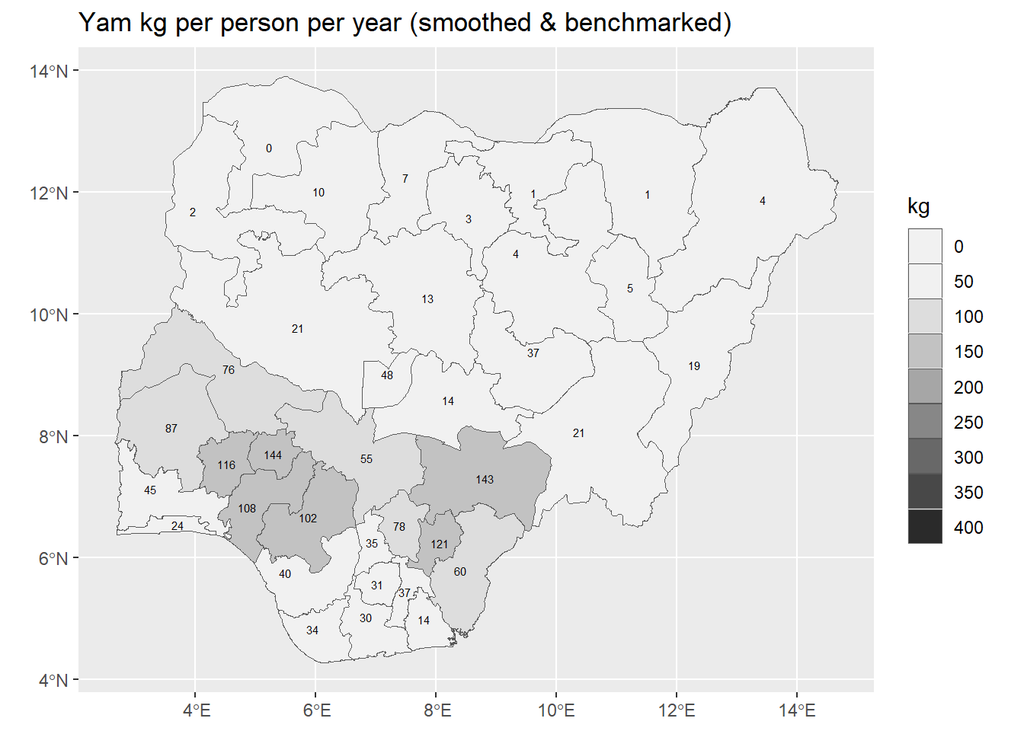

```r
ggplot(tidyterra::filter(vect_state_geo_GHS_crop, crop == "Yam")) +
  geom_spatvector(aes(fill = benchmarked_crop_equivalent_kg_person_year_state)) +
  geom_spatvector_text(aes(label = round(benchmarked_crop_equivalent_kg_person_year_state)), size = 2) +
  scale_fill_stepsn(
    n.breaks = 10,
    limits = c(0, 400),
    colours = hcl.colors(palette = "Grays", 10, rev = T),
    guide = "legend",
    na.value = "pink",
    labels = scales::comma
  ) +
  labs(title = "Yam kg per person per year (smoothed & benchmarked)", fill = "kg") +
  theme(
    plot.title = element_markdown(),
    legend.title = element_markdown(),
    axis.title = element_blank()
  )
```

# 2030 Urbanisation Model

We would like to develop a scenario for changes in the diet in Nigeria in 2030, and model those changes. Our objective is to show spatially how that scenario would affect state-level consumption of 5 crops: maize, rice, cowpea, cassava and sweet potato.

We need a simple model which shows how urbanisation would affect the per capita consumption of those crops. The important thing is to show how differing rates of urbanisation would affect the existing spatial pattern.

Per capita consumption = rural level × [(1 − u) + u × m], where u is the urban population share and m is the urban-to-rural ratio for that crop. The change from urbanisation is therefore rural level × (m − 1) × Δu.

Evidence on direction. The multipliers are my judgement, because I found no quantified urban-versus-rural kilograms.

Household survey data show rural families eating more maize and cassava (Petrikova et al, 2023). Rice demand is higher in urban areas, and rural demand for maize is lower (Ashagidigbi, 2019). Rice consumption is nearly universal in urban households (99% versus 90% in rural). Cassava roots are eaten far less in urban households (4% versus 18%), but cassava flour is similar (18% versus 16%). Sweet potato is slightly lower in urban households (14% versus 17%).

| Crop | Urban/rural multiplier (central) | Plausible range | Confidence |
| --- | --- | --- | --- |
| Rice | 1.4 | 1.2–1.8 | Direction strong, size weak |
| Maize | 0.7 | 0.5–0.9 | Direction good |
| Cassava | 0.8 (roots ~0.5, gari/flour ~1.0) | 0.6–1.0 | Depends on the form eaten |
| Cowpea | 0.95 | 0.7–1.2 | No clear signal |
| Sweet potato | 0.75 | 0.5–1.0 | Weak, mainly NW/NE |

Rural diets are also changing. Rice consumption rose from 86% to 92% of households between 2010 and 2018 (a similar rise appears in maize flour). Model a separate time trend so you don’t credit all rice growth to urbanisation (Petrikova et al, 2023).

Adoption lag. New urban residents probably don’t adopt urban diets immediately. Consider applying m only partially to the newly urbanised share.

## Population rural/urban splits

MICS puts the national urban share at 42.5% of the population, well below the UN-based 54.9% for 2025. That is partly a definitional gap: its sampling frame is the updated 2006 census, which classifies enumeration areas as urban or rural by fixed size cut-offs.

Treat the MICS state shares as the ~2021 baseline. Apply the UN’s national change as a uniform shift on the logit scale. Going from 2021 to 2025 that is about +0.09, and to 2030 about +0.29, derived from the UN national path of roughly 52% (2020), 54.9% (2025) and 59.6% (2030). Report the results as MICS-definition urban shares for 2025 and 2030. States near 50% would gain the most (roughly +2 points by 2025 and +7 by 2030), and states near 5% or 95% almost nothing.

I took the MICS values as the 2021 baseline and applied one uniform shift on the logit scale to every state. The shift is taken from the UN national path (about 52% in 2020, 54.9% in 2025, 59.6% in 2030). That works out to +0.095 for 2021→2025 and +0.287 for 2021→2030.

### Observations

- Some state values look odd against the NDHS. Ebonyi (0.84) and Anambra (0.85) are very high, and Akwa Ibom (0.07), Abia (0.19) and Cross River (0.19) are very low. They are probably artefacts of the 2006 enumeration-area classification.
- Borno (0.55) covers only the 7 accessible LGAs, which include Maiduguri, so it likely overstates the state.
- Uniform logit shift: the shift is the same everywhere, so it doesn’t capture faster urbanisation in fast-growing states. If you have state-specific growth, apply it as a state-specific shift.

### Load population splits

```r
df_MICS_urban_rural <- read.csv("tab_data/nigeria_state_urban_share_MICS_based.csv")

df_MICS_urban_rural |>
  DT::datatable(
    rownames = F,
    colnames=c("State", "Zone", "Urban share 2021 (MICS)",  "Urban share 2025 (Projected)", "Urban share 2030 (Projected)"),
    caption = "Urban-Rural population share 2021-2030",
    selection = list(mode = "none"),
    editable = FALSE,
    options = list(
      digits = 0,
      scrollX = TRUE,
      scrollCollapse = TRUE,
      # autoWidth = TRUE,
      fixedColumns = list(leftColumns = 2),
      lengthMenu = c(15, 40),
      pageLength = 15
    ))
```

| State | Zone | Urban share 2021 (MICS) | Urban share 2025 (Projected) | Urban share 2030 (Projected) |
| --- | --- | --- | --- | --- |
| Abia | SE | 0.192 | 0.207 | 0.24 |
| Adamawa | NE | 0.225 | 0.242 | 0.279 |
| Akwa Ibom | SS | 0.072 | 0.079 | 0.094 |
| Anambra | SE | 0.853 | 0.864 | 0.885 |
| Bauchi | NE | 0.137 | 0.149 | 0.175 |
| Bayelsa | SS | 0.309 | 0.33 | 0.373 |
| Benue | NC | 0.158 | 0.171 | 0.2 |
| Borno | NE | 0.548 | 0.571 | 0.618 |
| Cross River | SS | 0.186 | 0.201 | 0.233 |
| Delta | SS | 0.559 | 0.582 | 0.628 |

[output cut: 27 more lines]

## Urbanisation Model implementation

Because urban consumption is defined as rural consumption times a multiplier, the 2023 split can be solved directly, and the projection reduces to one ratio.

Notation: T is the 2023 total per capita for a crop in a state, u is the urban share, m is the urban/rural multiplier for that crop, R is rural per capita and U is urban per capita.

1. Urban share in 2023. Interpolate between our 2021 and 2025 values. The midpoint is fine: u₂₃ = (u₂₁ + u₂₅)/2. Interpolating on the logit scale instead makes a negligible difference.
2. Split the 2023 total. Since T = (1 − u₂₃)·R + u₂₃·m·R:

R₂₃ = T ÷ [1 + u₂₃(m − 1)] U₂₃ = m × R₂₃

This reproduces T exactly when you re-weight.

3. Project to 2030. Hold R and U constant and let only the urban share change:

T₂₀₃₀ = R₂₃ × [1 + u₂₀₃₀(m − 1)] Equivalently: T₂₀₃₀ = T₂₃ × [1 + u₂₀₃₀(m − 1)] ÷ [1 + u₂₃(m − 1)]

The second form needs only T and the two urban shares per state and crop. The change in a crop’s per capita consumption depends only on m and on how far u moves.

Worked example (Kano, T₂₃ = 40 kg): u₂₃ = (0.438 + 0.461)/2 = 0.450 and u₂₀₃₀ = 0.509.

| Crop | m | Rural (kg) | Urban (kg) | 2030 total (kg) | Change |
| --- | --- | --- | --- | --- | --- |
| Rice | 1.4 | 33.9 | 47.5 | 40.8 | +2.0% |
| Maize | 0.7 | 46.2 | 32.3 | 39.2 | −2.1% |

In the table, T = 40 kg is applied to each crop separately. In our data each crop will have its own T.

```r
df_crop_state_results_benchmarked_smoothed <-
read.csv("tab_data/GHS food per capita outputs/crop_state_results_benchmarked_smoothed.csv")
```

#### Cassava 2030 consumption

The biggest percentage changes in this model would be for Borno state, while the biggest in kilograms is for Rivers state. The differences due to urbanisation would be small, however.

```r
df_cassava_consumption <- filter(df_crop_state_results_benchmarked_smoothed, crop == "Cassava") |>
  select(state, benchmarked_crop_equivalent_kg_person_year_state)

df_cassava_consumption_2030 <- left_join(df_MICS_urban_rural, df_cassava_consumption, by = "state" )

cassava_multiplier <- 0.8

# u₂₃ = (u₂₁ + u₂₅)/2
# R₂₃ = T ÷ [1 + u₂₃(m − 1)]
# U₂₃ = m × R₂
# T₂₀₃₀ = R₂₃ × [1 + u₂₀₃₀(m − 1)

df_cassava_consumption_2030 <- df_cassava_consumption_2030 |>
  mutate(urban_share_2023 = (urban_share_2021_MICS + urban_share_2025)/2) |>
  mutate(rural_cassava_cons_2023 = (benchmarked_crop_equivalent_kg_person_year_state / (1 + (urban_share_2023 * (cassava_multiplier - 1))))) |>
  mutate(urban_cassava_cons_2023 = rural_cassava_cons_2023 * cassava_multiplier) |>
  mutate(benchmarked_crop_equivalent_kg_person_year_state_2030 =
           (rural_cassava_cons_2023 * (1 - urban_share_2030)) +
           (urban_cassava_cons_2023 * urban_share_2030)) |>
  mutate(change_pc_capita_kg = benchmarked_crop_equivalent_kg_person_year_state_2030 - benchmarked_crop_equivalent_kg_person_year_state) |>
  mutate(change_pc_capita_pc = (change_pc_capita_kg / benchmarked_crop_equivalent_kg_person_year_state) * 100 )


df_cassava_consumption_2030 <- df_cassava_consumption_2030 |>
  mutate(rural_cassava_cons_2023 = as.numeric(prettyunits::pretty_round(rural_cassava_cons_2023, digits = 2)))|>
  mutate(urban_cassava_cons_2023 = as.numeric(prettyunits::pretty_round(urban_cassava_cons_2023, digits = 2)))|>
  mutate(total_cassava_cons_2023 = as.numeric(prettyunits::pretty_round(benchmarked_crop_equivalent_kg_person_year_state, digits = 2)))|>
  mutate(total_cassava_cons_2030 = as.numeric(prettyunits::pretty_round(benchmarked_crop_equivalent_kg_person_year_state_2030, digits = 2)))|>
  mutate(change_pc_capita_cassava_kg = as.numeric(prettyunits::pretty_round(change_pc_capita_kg, digits = 2))) |>
  mutate(change_pc_capita_cassava_pc = as.numeric(prettyunits::pretty_round(change_pc_capita_pc, digits = 2)))

select(df_cassava_consumption_2030, state, rural_cassava_cons_2023, urban_share_2023, urban_cassava_cons_2023,total_cassava_cons_2023, urban_share_2030, total_cassava_cons_2030, change_pc_capita_cassava_kg, change_pc_capita_cassava_pc )   |>
  DT::datatable(
    rownames = F,
    colnames=c("State", "rural consumption 2023", "urban share 2023",   "urban consumption 2023",   "total consumption 2023", "urban share 2030"    , "total consumption 2030", "change consumption (kg)", "change consumption (%)"),
    caption = "",
    selection = list(mode = "none"),
    editable = FALSE,
    options = list(
      digits = 0,
      scrollX = TRUE,
      scrollCollapse = TRUE,
      # autoWidth = TRUE,
      fixedColumns = list(leftColumns = 2),
      lengthMenu = c(15, 40),
      pageLength = 15
    ))
```

| State | rural consumption 2023 | urban share 2023 | urban consumption 2023 | total consumption 2023 | urban share 2030 | total consumption 2030 | change consumption (kg) | change consumption (%) |
| --- | --- | --- | --- | --- | --- | --- | --- | --- |
| Abia | 140.77 | 0.1995 | 112.61 | 135.15 | 0.24 | 134.01 | -1.14 | -0.84 |
| Adamawa | 42.21 | 0.2335 | 33.77 | 40.24 | 0.279 | 39.86 | -0.38 | -0.95 |
| Akwa Ibom | 287.26 | 0.0755 | 229.81 | 282.92 | 0.094 | 281.86 | -1.06 | -0.38 |
| Anambra | 118.14 | 0.8585 | 94.51 | 97.85 | 0.885 | 97.23 | -0.63 | -0.64 |
| Bauchi | 83.67 | 0.143 | 66.94 | 81.28 | 0.175 | 80.74 | -0.54 | -0.66 |
| Bayelsa | 260.18 | 0.3195 | 208.14 | 243.55 | 0.373 | 240.77 | -2.78 | -1.14 |
| Benue | 143.76 | 0.1645 | 115 | 139.03 | 0.2 | 138.01 | -1.02 | -0.73 |
| Borno | 37.06 | 0.5595 | 29.65 | 32.91 | 0.618 | 32.48 | -0.43 | -1.32 |
| Cross River | 256.57 | 0.1935 | 205.26 | 246.64 | 0.233 | 244.62 | -2.03 | -0.82 |
| Delta | 162.98 | 0.5705 | 130.39 | 144.39 | 0.628 | 142.51 | -1.87 | -1.3 |

[output cut: 27 more lines]

#### Cowpea 2030 consumption

The biggest percentage changes in this model are for a number of states that experience urbanisation - such as Borno, Rivers, Delta and Kaduna, while the biggest in kilograms is again for Rivers state. The differences due to urbanisation would be small, however.

```r
df_cowpea_consumption <- filter(df_crop_state_results_benchmarked_smoothed, crop == "Cowpea") |>
  select(state, benchmarked_crop_equivalent_kg_person_year_state)

df_cowpea_consumption_2030 <- left_join(df_MICS_urban_rural, df_cowpea_consumption, by = "state" )

cowpea_multiplier <- 0.95

# u₂₃ = (u₂₁ + u₂₅)/2
# R₂₃ = T ÷ [1 + u₂₃(m − 1)]
# U₂₃ = m × R₂
# T₂₀₃₀ = R₂₃ × [1 + u₂₀₃₀(m − 1)

df_cowpea_consumption_2030 <- df_cowpea_consumption_2030 |>
  mutate(urban_share_2023 = (urban_share_2021_MICS + urban_share_2025)/2) |>
  mutate(rural_cowpea_cons_2023 = (benchmarked_crop_equivalent_kg_person_year_state / (1 + (urban_share_2023 * (cowpea_multiplier - 1))))) |>
  mutate(urban_cowpea_cons_2023 = rural_cowpea_cons_2023 * cowpea_multiplier) |>
  mutate(benchmarked_crop_equivalent_kg_person_year_state_2030 =
           (rural_cowpea_cons_2023 * (1 - urban_share_2030)) +
           (urban_cowpea_cons_2023 * urban_share_2030)) |>
  mutate(change_pc_capita_kg = benchmarked_crop_equivalent_kg_person_year_state_2030 - benchmarked_crop_equivalent_kg_person_year_state) |>
  mutate(change_pc_capita_pc = (change_pc_capita_kg / benchmarked_crop_equivalent_kg_person_year_state) * 100 )


df_cowpea_consumption_2030 <- df_cowpea_consumption_2030 |>
  mutate(rural_cowpea_cons_2023 = as.numeric(prettyunits::pretty_round(rural_cowpea_cons_2023, digits = 2)))|>
  mutate(urban_cowpea_cons_2023 = as.numeric(prettyunits::pretty_round(urban_cowpea_cons_2023, digits = 2)))|>
  mutate(total_cowpea_cons_2023 = as.numeric(prettyunits::pretty_round(benchmarked_crop_equivalent_kg_person_year_state, digits = 2)))|>
  mutate(total_cowpea_cons_2030 = as.numeric(prettyunits::pretty_round(benchmarked_crop_equivalent_kg_person_year_state_2030, digits = 2)))|>
  mutate(change_pc_capita_cowpea_kg = as.numeric(prettyunits::pretty_round(change_pc_capita_kg, digits = 2))) |>
  mutate(change_pc_capita_cowpea_pc = as.numeric(prettyunits::pretty_round(change_pc_capita_pc, digits = 2)))

select(df_cowpea_consumption_2030, state, rural_cowpea_cons_2023, urban_share_2023, urban_cowpea_cons_2023,total_cowpea_cons_2023, urban_share_2030, total_cowpea_cons_2030, change_pc_capita_cowpea_kg, change_pc_capita_cowpea_pc)   |>
  DT::datatable(
    rownames = F,
    colnames=c("State", "rural consumption 2023", "urban share 2023",   "urban consumption 2023",   "total consumption 2023", "urban share 2030"    , "total consumption 2030", "change consumption (kg)", "change consumption (%)"),
    caption = "",
    selection = list(mode = "none"),
    editable = FALSE,
    options = list(
      digits = 0,
      scrollX = TRUE,
      scrollCollapse = TRUE,
      # autoWidth = TRUE,
      fixedColumns = list(leftColumns = 2),
      lengthMenu = c(15, 40),
      pageLength = 15
    ))
```

| State | rural consumption 2023 | urban share 2023 | urban consumption 2023 | total consumption 2023 | urban share 2030 | total consumption 2030 | change consumption (kg) | change consumption (%) |
| --- | --- | --- | --- | --- | --- | --- | --- | --- |
| Abia | 12.52 | 0.1995 | 11.89 | 12.4 | 0.24 | 12.37 | -0.03 | -0.2 |
| Adamawa | 7.48 | 0.2335 | 7.11 | 7.4 | 0.279 | 7.38 | -0.02 | -0.23 |
| Akwa Ibom | 15.54 | 0.0755 | 14.76 | 15.48 | 0.094 | 15.46 | -0.01 | -0.09 |
| Anambra | 9.97 | 0.8585 | 9.47 | 9.54 | 0.885 | 9.53 | -0.01 | -0.14 |
| Bauchi | 11.09 | 0.143 | 10.54 | 11.02 | 0.175 | 11 | -0.02 | -0.16 |
| Bayelsa | 17.42 | 0.3195 | 16.55 | 17.14 | 0.373 | 17.09 | -0.05 | -0.27 |
| Benue | 7.12 | 0.1645 | 6.76 | 7.06 | 0.2 | 7.05 | -0.01 | -0.18 |
| Borno | 5.12 | 0.5595 | 4.87 | 4.98 | 0.618 | 4.96 | -0.01 | -0.3 |
| Cross River | 11.78 | 0.1935 | 11.19 | 11.67 | 0.233 | 11.64 | -0.02 | -0.2 |
| Delta | 15.89 | 0.5705 | 15.09 | 15.43 | 0.628 | 15.39 | -0.05 | -0.3 |

[output cut: 27 more lines]

#### Maize 2030 consumption

The biggest percentage changes in this model are again for a number of states that experience urbanisation - such as Borno, Rivers, Delta and Kaduna, while the biggest in kilograms is for Plateau state. The differences due to urbanisation would be small, however.

```r
df_maize_consumption <- filter(df_crop_state_results_benchmarked_smoothed, crop == "Maize") |>
  select(state, benchmarked_crop_equivalent_kg_person_year_state)

df_maize_consumption_2030 <- left_join(df_MICS_urban_rural, df_maize_consumption, by = "state" )

maize_multiplier <- 0.7

# u₂₃ = (u₂₁ + u₂₅)/2
# R₂₃ = T ÷ [1 + u₂₃(m − 1)]
# U₂₃ = m × R₂
# T₂₀₃₀ = R₂₃ × [1 + u₂₀₃₀(m − 1)

df_maize_consumption_2030 <- df_maize_consumption_2030 |>
  mutate(urban_share_2023 = (urban_share_2021_MICS + urban_share_2025)/2) |>
  mutate(rural_maize_cons_2023 = (benchmarked_crop_equivalent_kg_person_year_state / (1 + (urban_share_2023 * (maize_multiplier - 1))))) |>
  mutate(urban_maize_cons_2023 = rural_maize_cons_2023 * maize_multiplier) |>
  mutate(benchmarked_crop_equivalent_kg_person_year_state_2030 =
           (rural_maize_cons_2023 * (1 - urban_share_2030)) +
           (urban_maize_cons_2023 * urban_share_2030)) |>
  mutate(change_pc_capita_kg = benchmarked_crop_equivalent_kg_person_year_state_2030 - benchmarked_crop_equivalent_kg_person_year_state) |>
  mutate(change_pc_capita_pc = (change_pc_capita_kg / benchmarked_crop_equivalent_kg_person_year_state) * 100 )


df_maize_consumption_2030 <- df_maize_consumption_2030 |>
  mutate(rural_maize_cons_2023 = as.numeric(prettyunits::pretty_round(rural_maize_cons_2023, digits = 2)))|>
  mutate(urban_maize_cons_2023 = as.numeric(prettyunits::pretty_round(urban_maize_cons_2023, digits = 2)))|>
  mutate(total_maize_cons_2023 = as.numeric(prettyunits::pretty_round(benchmarked_crop_equivalent_kg_person_year_state, digits = 2)))|>
  mutate(total_maize_cons_2030 = as.numeric(prettyunits::pretty_round(benchmarked_crop_equivalent_kg_person_year_state_2030, digits = 2)))|>
  mutate(change_pc_capita_maize_kg = as.numeric(prettyunits::pretty_round(change_pc_capita_kg, digits = 2))) |>
  mutate(change_pc_capita_maize_pc = as.numeric(prettyunits::pretty_round(change_pc_capita_pc, digits = 2)))

select(df_maize_consumption_2030, state, rural_maize_cons_2023, urban_share_2023, urban_maize_cons_2023,total_maize_cons_2023, urban_share_2030, total_maize_cons_2030, change_pc_capita_maize_kg, change_pc_capita_maize_pc)   |>
  DT::datatable(
    rownames = F,
    colnames=c("State", "rural consumption 2023", "urban share 2023",   "urban consumption 2023",   "total consumption 2023", "urban share 2030"    , "total consumption 2030", "change consumption (kg)", "change consumption (%)"),
    caption = "",
    selection = list(mode = "none"),
    editable = FALSE,
    options = list(
      digits = 0,
      scrollX = TRUE,
      scrollCollapse = TRUE,
      # autoWidth = TRUE,
      fixedColumns = list(leftColumns = 2),
      lengthMenu = c(15, 40),
      pageLength = 15
    ))
```

| State | rural consumption 2023 | urban share 2023 | urban consumption 2023 | total consumption 2023 | urban share 2030 | total consumption 2030 | change consumption (kg) | change consumption (%) |
| --- | --- | --- | --- | --- | --- | --- | --- | --- |
| Abia | 10.35 | 0.1995 | 7.24 | 9.73 | 0.24 | 9.6 | -0.13 | -1.29 |
| Adamawa | 42.73 | 0.2335 | 29.91 | 39.74 | 0.279 | 39.16 | -0.58 | -1.47 |
| Akwa Ibom | 1.87 | 0.0755 | 1.31 | 1.83 | 0.094 | 1.82 | -0.01 | -0.57 |
| Anambra | 12.84 | 0.8585 | 8.99 | 9.53 | 0.885 | 9.43 | -0.1 | -1.07 |
| Bauchi | 24.53 | 0.143 | 17.17 | 23.48 | 0.175 | 23.24 | -0.24 | -1 |
| Bayelsa | 1.89 | 0.3195 | 1.32 | 1.71 | 0.373 | 1.68 | -0.03 | -1.78 |
| Benue | 21.76 | 0.1645 | 15.24 | 20.69 | 0.2 | 20.46 | -0.23 | -1.12 |
| Borno | 32.36 | 0.5595 | 22.65 | 26.93 | 0.618 | 26.36 | -0.57 | -2.11 |
| Cross River | 3.76 | 0.1935 | 2.63 | 3.54 | 0.233 | 3.49 | -0.04 | -1.26 |
| Delta | 7.79 | 0.5705 | 5.45 | 6.45 | 0.628 | 6.32 | -0.13 | -2.08 |

[output cut: 27 more lines]

#### Rice 2030 consumption

The biggest percentage changes in this model are in Kaduna and Kano, while the biggest in kilograms is for Rivers state. The differences due to urbanisation would be small, however.

```r
df_rice_consumption <- filter(df_crop_state_results_benchmarked_smoothed, crop == "Rice") |>
  select(state, benchmarked_crop_equivalent_kg_person_year_state)

df_rice_consumption_2030 <- left_join(df_MICS_urban_rural, df_rice_consumption, by = "state" )

rice_multiplier <- 1.4

# u₂₃ = (u₂₁ + u₂₅)/2
# R₂₃ = T ÷ [1 + u₂₃(m − 1)]
# U₂₃ = m × R₂
# T₂₀₃₀ = R₂₃ × [1 + u₂₀₃₀(m − 1)

df_rice_consumption_2030 <- df_rice_consumption_2030 |>
  mutate(urban_share_2023 = (urban_share_2021_MICS + urban_share_2025)/2) |>
  mutate(rural_rice_cons_2023 = (benchmarked_crop_equivalent_kg_person_year_state / (1 + (urban_share_2023 * (rice_multiplier - 1))))) |>
  mutate(urban_rice_cons_2023 = rural_rice_cons_2023 * rice_multiplier) |>
  mutate(benchmarked_crop_equivalent_kg_person_year_state_2030 =
           (rural_rice_cons_2023 * (1 - urban_share_2030)) +
           (urban_rice_cons_2023 * urban_share_2030)) |>
  mutate(change_pc_capita_kg = benchmarked_crop_equivalent_kg_person_year_state_2030 - benchmarked_crop_equivalent_kg_person_year_state) |>
  mutate(change_pc_capita_pc = (change_pc_capita_kg / benchmarked_crop_equivalent_kg_person_year_state) * 100 )


df_rice_consumption_2030 <- df_rice_consumption_2030 |>
  mutate(rural_rice_cons_2023 = as.numeric(prettyunits::pretty_round(rural_rice_cons_2023, digits = 2)))|>
  mutate(urban_rice_cons_2023 = as.numeric(prettyunits::pretty_round(urban_rice_cons_2023, digits = 2)))|>
  mutate(total_rice_cons_2023 = as.numeric(prettyunits::pretty_round(benchmarked_crop_equivalent_kg_person_year_state, digits = 2)))|>
  mutate(total_rice_cons_2030 = as.numeric(prettyunits::pretty_round(benchmarked_crop_equivalent_kg_person_year_state_2030, digits = 2)))|>
  mutate(change_pc_capita_rice_kg = as.numeric(prettyunits::pretty_round(change_pc_capita_kg, digits = 2))) |>
  mutate(change_pc_capita_rice_pc = as.numeric(prettyunits::pretty_round(change_pc_capita_pc, digits = 2)))

select(df_rice_consumption_2030, state, rural_rice_cons_2023, urban_share_2023, urban_rice_cons_2023,total_rice_cons_2023, urban_share_2030, total_rice_cons_2030, change_pc_capita_rice_kg, change_pc_capita_rice_pc)   |>
  DT::datatable(
    rownames = F,
    colnames=c("State", "rural consumption 2023", "urban share 2023",   "urban consumption 2023",   "total consumption 2023", "urban share 2030"    , "total consumption 2030", "change consumption (kg)", "change consumption (%)"),
    caption = "",
    selection = list(mode = "none"),
    editable = FALSE,
    options = list(
      digits = 0,
      scrollX = TRUE,
      scrollCollapse = TRUE,
      # autoWidth = TRUE,
      fixedColumns = list(leftColumns = 2),
      lengthMenu = c(15, 40),
      pageLength = 15
    ))
```

| State | rural consumption 2023 | urban share 2023 | urban consumption 2023 | total consumption 2023 | urban share 2030 | total consumption 2030 | change consumption (kg) | change consumption (%) |
| --- | --- | --- | --- | --- | --- | --- | --- | --- |
| Abia | 23.9 | 0.1995 | 33.46 | 25.81 | 0.24 | 26.19 | 0.39 | 1.5 |
| Adamawa | 15.74 | 0.2335 | 22.04 | 17.21 | 0.279 | 17.5 | 0.29 | 1.66 |
| Akwa Ibom | 20.11 | 0.0755 | 28.15 | 20.72 | 0.094 | 20.87 | 0.15 | 0.72 |
| Anambra | 21.49 | 0.8585 | 30.09 | 28.87 | 0.885 | 29.1 | 0.23 | 0.79 |
| Bauchi | 20.78 | 0.143 | 29.09 | 21.97 | 0.175 | 22.23 | 0.27 | 1.21 |
| Bayelsa | 24.75 | 0.3195 | 34.65 | 27.91 | 0.373 | 28.44 | 0.53 | 1.9 |
| Benue | 17.32 | 0.1645 | 24.25 | 18.46 | 0.2 | 18.71 | 0.25 | 1.33 |
| Borno | 14.3 | 0.5595 | 20.03 | 17.51 | 0.618 | 17.84 | 0.33 | 1.91 |
| Cross River | 15.42 | 0.1935 | 21.58 | 16.61 | 0.233 | 16.85 | 0.24 | 1.47 |
| Delta | 27.75 | 0.5705 | 38.85 | 34.08 | 0.628 | 34.72 | 0.64 | 1.87 |

[output cut: 27 more lines]

#### Sweet Potato 2030 consumption

The biggest percentage changes in this model would be for Borno state, while the biggest in kilograms is for Zamfara state. The differences due to urbanisation would be small, however.

```r
df_spot_consumption <- filter(df_crop_state_results_benchmarked_smoothed, crop == "Sweet potato") |>
  select(state, benchmarked_crop_equivalent_kg_person_year_state)

df_spot_consumption_2030 <- left_join(df_MICS_urban_rural, df_spot_consumption, by = "state" )

spot_multiplier <- 0.75

# u₂₃ = (u₂₁ + u₂₅)/2
# R₂₃ = T ÷ [1 + u₂₃(m − 1)]
# U₂₃ = m × R₂
# T₂₀₃₀ = R₂₃ × [1 + u₂₀₃₀(m − 1)

df_spot_consumption_2030 <- df_spot_consumption_2030 |>
  mutate(urban_share_2023 = (urban_share_2021_MICS + urban_share_2025)/2) |>
  mutate(rural_spot_cons_2023 = (benchmarked_crop_equivalent_kg_person_year_state / (1 + (urban_share_2023 * (spot_multiplier - 1))))) |>
  mutate(urban_spot_cons_2023 = rural_spot_cons_2023 * spot_multiplier) |>
  mutate(benchmarked_crop_equivalent_kg_person_year_state_2030 =
           (rural_spot_cons_2023 * (1 - urban_share_2030)) +
           (urban_spot_cons_2023 * urban_share_2030)) |>
  mutate(change_pc_capita_kg = benchmarked_crop_equivalent_kg_person_year_state_2030 - benchmarked_crop_equivalent_kg_person_year_state) |>
  mutate(change_pc_capita_pc = (change_pc_capita_kg / benchmarked_crop_equivalent_kg_person_year_state) * 100 )


df_spot_consumption_2030 <- df_spot_consumption_2030 |>
  mutate(rural_spot_cons_2023 = as.numeric(prettyunits::pretty_round(rural_spot_cons_2023, digits = 2)))|>
  mutate(urban_spot_cons_2023 = as.numeric(prettyunits::pretty_round(urban_spot_cons_2023, digits = 2)))|>
  mutate(total_spot_cons_2023 = as.numeric(prettyunits::pretty_round(benchmarked_crop_equivalent_kg_person_year_state, digits = 2)))|>
  mutate(total_spot_cons_2030 = as.numeric(prettyunits::pretty_round(benchmarked_crop_equivalent_kg_person_year_state_2030, digits = 2)))|>
  mutate(change_pc_capita_spot_kg = as.numeric(prettyunits::pretty_round(change_pc_capita_kg, digits = 2))) |>
  mutate(change_pc_capita_spot_pc = as.numeric(prettyunits::pretty_round(change_pc_capita_pc, digits = 2)))

select(df_spot_consumption_2030, state, rural_spot_cons_2023, urban_share_2023, urban_spot_cons_2023,total_spot_cons_2023, urban_share_2030, total_spot_cons_2030, change_pc_capita_spot_kg, change_pc_capita_spot_pc)   |>
  DT::datatable(
    rownames = F,
    colnames=c("State", "rural consumption 2023", "urban share 2023",   "urban consumption 2023",   "total consumption 2023", "urban share 2030"    , "total consumption 2030", "change consumption (kg)", "change consumption (%)"),
    caption = "",
    selection = list(mode = "none"),
    editable = FALSE,
    options = list(
      digits = 0,
      scrollX = TRUE,
      scrollCollapse = TRUE,
      # autoWidth = TRUE,
      fixedColumns = list(leftColumns = 2),
      lengthMenu = c(15, 40),
      pageLength = 15
    ))
```

| State | rural consumption 2023 | urban share 2023 | urban consumption 2023 | total consumption 2023 | urban share 2030 | total consumption 2030 | change consumption (kg) | change consumption (%) |
| --- | --- | --- | --- | --- | --- | --- | --- | --- |
| Abia | 2.24 | 0.1995 | 1.68 | 2.13 | 0.24 | 2.1 | -0.02 | -1.07 |
| Adamawa | 8.84 | 0.2335 | 6.63 | 8.32 | 0.279 | 8.22 | -0.1 | -1.21 |
| Akwa Ibom | 1.42 | 0.0755 | 1.07 | 1.4 | 0.094 | 1.39 | -0.01 | -0.47 |
| Anambra | 4.74 | 0.8585 | 3.55 | 3.72 | 0.885 | 3.69 | -0.03 | -0.84 |
| Bauchi | 4.79 | 0.143 | 3.59 | 4.62 | 0.175 | 4.58 | -0.04 | -0.83 |
| Bayelsa | 9.94 | 0.3195 | 7.46 | 9.15 | 0.373 | 9.02 | -0.13 | -1.45 |
| Benue | 10.77 | 0.1645 | 8.08 | 10.33 | 0.2 | 10.23 | -0.1 | -0.93 |
| Borno | 3.21 | 0.5595 | 2.41 | 2.76 | 0.618 | 2.72 | -0.05 | -1.7 |
| Cross River | 5.42 | 0.1935 | 4.07 | 5.16 | 0.233 | 5.11 | -0.05 | -1.04 |
| Delta | 4.58 | 0.5705 | 3.44 | 3.93 | 0.628 | 3.86 | -0.07 | -1.68 |

[output cut: 27 more lines]

```r
df_crop_consumption_2030 <- left_join(
  select(
    df_cassava_consumption_2030,
    state,
    zone,
    total_cassava_cons_2030
  ),
  left_join(
    select(df_cowpea_consumption_2030, state, total_cowpea_cons_2030),
    left_join(
      select(df_maize_consumption_2030, state, total_maize_cons_2030),
      left_join(
        select(df_rice_consumption_2030, state, total_rice_cons_2030),
        select(df_spot_consumption_2030, state, total_spot_cons_2030),
        by = "state"
      ),
      by = "state"
    ),
    by = "state"
  ),
  by = "state"
)


write_csv(
  df_crop_consumption_2030,
  "tab_data/GHS food per capita outputs/crop_state_results_benchmarked_smoothed_2030.csv"
)
```

# Appendix 1: Potential extra checks

**NoteNumber of days of consumption**

Section 5C – Aggregate Food Consumption file (`sect5c_harvestw5.dta`) represents an additional opportunity to check the validity of our results:

It has 56,580 observations and records the number of days the household consumed each food-group item during the previous seven days.

We did not use that for the kg calculation, but it was potentially useful as a quality check.

For example, if our calculation says a household consumed 50 kg of maize flour in seven days, we can check whether that household reported consuming maize flour on some/all of the seven days. It could help identify implausible conversion-factor results.

**CautionCheck the results**

Before we start converting food products into crops, we need to run the script and look specifically at state_sample and a few major products such as maize, cassava, rice and yam.

There is then a very useful diagnostic we can do: compare the state-level estimates aggregated back to Nigeria against the corresponding national/zone estimates. That will tell us whether the weighting and state-domain calculations are behaving as expected before we build the crop-equivalent calculations on top of them.

**NoteSensitivity Analysis**

We did not use the confidence intervals, coefficient of variation, or the upper and lower food to crop conversion factors in our analysis.

These could potentially be combined to show a range of results which could be incoporated in the sub national BPI for Nigeria.

## References

Asare-Marfo, Dorene, Ekin Birol, Carolina Gonzalez, et al. 2013. *Prioritizing Countries for Biofortifcation Interventions Using Country-Level Data*. Vol. 11. HarvestPlus.

Herrington, C., J. Funes, K. Lividini, et al. 2018. “Subnational Prioritization for Biofortification Interventions in Nigeria.” *30th International Conference of Agricultural Economists* (Vancouver, British Columbia, Canada), July. https://doi.org/10.22004/AG.ECON.277092.